# R6_and_R7

2023-11-27

# Influence of Webinars and Seminars on Students’ Academic Performance

##### RegNo 2347161

```r
library(GGally)
library(dplyr)
library(tidyverse)
```

```r
library(ggplot2)
library(vcd)
library(reshape2)
library(fmsb)
library(gridExtra)
path <- "./data.csv"
data <- read.csv(path)
str(data)
```

```
## 'data.frame':    125 obs. of  25 variables:
##  $ Timestamp                                                                                                              : chr  "11/12/2023 20:00:44" "11/12/2023 20:09:51" "11/12/2023 20:12:53" "11/12/2023 20:14:08" ...
##  $ Email.Address                                                                                                          : chr  "brunda1999rbru@gmail.com" "Sujan Gowda S" "The high one" "Siddesh S.J" ...
##  $ Score                                                                                                                  : logi  NA NA NA NA NA NA ...
##  $ What.is.your.current.level.of.education.                                                                               : chr  "Undergraduate (Bachelor's degree)" "Graduate (Master's or higher)" "Graduate (Master's or higher)" "Graduate (Master's or higher)" ...
##  $ Do.you.attend.webinars.and.seminars.related.to.your.study.                                                             : chr  "Neutral" "Agree" "Neutral" "Agree" ...
##  $ Have.you.participated.in.both.seminars.and.webinars.for.educational.purposes.                                          : chr  "Yes" "Yes" "Yes" "Yes" ...
##  $ Do.you.use.online.learning.resources..such.as.webinars..in.your.education.                                             : chr  "Yes" "Yes" "Yes" "No" ...
##  $ Perception.of.Webinars...Seminars..I.believe.seminars.and.webinars.are.effective.for.enhancing.student.engagement.     : chr  "Agree" "Agree" "Strongly disagree" "Agree" ...
##  $ Perception.of.Webinars...Seminars..The.convenience.of.webinars.influences.students..participation..                    : chr  "Agree" "Agree" "Disagree" "Neutral" ...
##  $ Perception.of.Webinars...Seminars..Webinars.are.better.at.accommodating.students..busy.schedules.compared.to.seminars..: chr  "Agree" "Strongly agree" "Strongly disagree" "Neutral" ...
##  $ Perception.of.Webinars...Seminars..Peer.interaction.is.essential.for.student.learning.in.webinars..                    : chr  "Strongly agree" "Strongly agree" "Disagree" "Agree" ...
##  $ Perception.of.Webinars...Seminars..Seminars.encourage.active.participation.among.students..                            : chr  "Neutral" "Strongly agree" "Strongly disagree" "Disagree" ...
##  $ Technology...Interaction..Interactive.features.like.polls.and.quizzes.enhance.the.value.of.webinars.for.students..     : chr  "Agree" "Agree" "Strongly disagree" "Neutral" ...
##  $ Technology...Interaction..Webinars.provide.ample.opportunities.for.students.to.ask.questions..                         : chr  "Strongly agree" "Agree" "Neutral" "Strongly agree" ...
##  $ Technology...Interaction..The.ability.to.review.content.later.is.a.significant.advantage.of.webinars..                 : chr  "Agree" "Agree" "Strongly disagree" "Agree" ...
##  $ Technology...Interaction..Webinars.offer.face.to.face.discussions.with.instructors..                                   : chr  "Agree" "Agree" "Neutral" "Strongly agree" ...
##  $ Technology...Interaction..Real.time.feedback.in.seminars.is.more.effective.than.in.webinars..                          : chr  "Agree" "Agree" "Strongly disagree" "Neutral" ...
##  $ Preferences..Webinars.are.more.accessible.to.a.wider.audience.compared.to.seminars..                                   : chr  "B- Disagree" "D- Agree" "A- Strongly disagree" "D- Agree" ...
##  $ Preferences..Specialized.topics.are.best.suited.for.seminars..                                                         : chr  "D- Agree" "D- Agree" "C- Neutral" "C- Neutral" ...
##  $ Preferences..Webinars.offer.increased.scheduling.flexibility..                                                         : chr  "B- Disagree" "D- Agree" "A- Strongly disagree" "E- Strongly agree" ...
##  $ Preferences..Webinars.are.better.for.students.who.have.limited.transportation.options..                                : chr  "D- Agree" "D- Agree" "A- Strongly disagree" "E- Strongly agree" ...
##  $ Preferences..Webinars.slightly.affect.social.opportunities.for.students..                                              : chr  "D- Agree" "D- Agree" "C- Neutral" "E- Strongly agree" ...
##  $ X                                                                                                                      : logi  NA NA NA NA NA NA ...
##  $ X.1                                                                                                                    : logi  NA NA NA NA NA NA ...
##  $ How.many.hours.per.week.do.you.spend.on.online.learning.activities..including.webinars.and.seminars.                   : chr  "1-5 hours" "Less than 1 hour" "6-10 hours" "6-10 hours" ...
```

```r
seminars_effective  = factor(data$Perception.of.Webinars...Seminars..I.believe.seminars.and.webinars.are.effective.for.enhancing.student.engagement., levels = c("Strongly disagree", "Disagree", "Neutral", "Agree", "Strongly agree"), ordered = TRUE)
convenience_webinars = factor(data$Perception.of.Webinars...Seminars..The.convenience.of.webinars.influences.students..participation.., levels = c("Strongly disagree", "Disagree", "Neutral", "Agree", "Strongly agree"), ordered = TRUE)
accomodating_students = factor(data$Perception.of.Webinars...Seminars..Webinars.are.better.at.accommodating.students..busy.schedules.compared.to.seminars.., levels = c("Strongly disagree", "Disagree", "Neutral", "Agree", "Strongly agree"), ordered = TRUE)
peer_interaction = factor(data$Perception.of.Webinars...Seminars..Peer.interaction.is.essential.for.student.learning.in.webinars.., levels = c("Strongly disagree", "Disagree", "Neutral", "Agree", "Strongly agree"), ordered = TRUE)
encourage_participation = factor(data$Perception.of.Webinars...Seminars..Seminars.encourage.active.participation.among.students.., levels = c("Strongly disagree", "Disagree", "Neutral", "Agree", "Strongly agree"), ordered = TRUE)
perceptions = data.frame(seminars_effective, convenience_webinars, accomodating_students, peer_interaction, encourage_participation)
perceptions = na.omit(perceptions)
```

## Perceptions :

### 1. I believe seminars and webinars are effective for enhancing student engagement

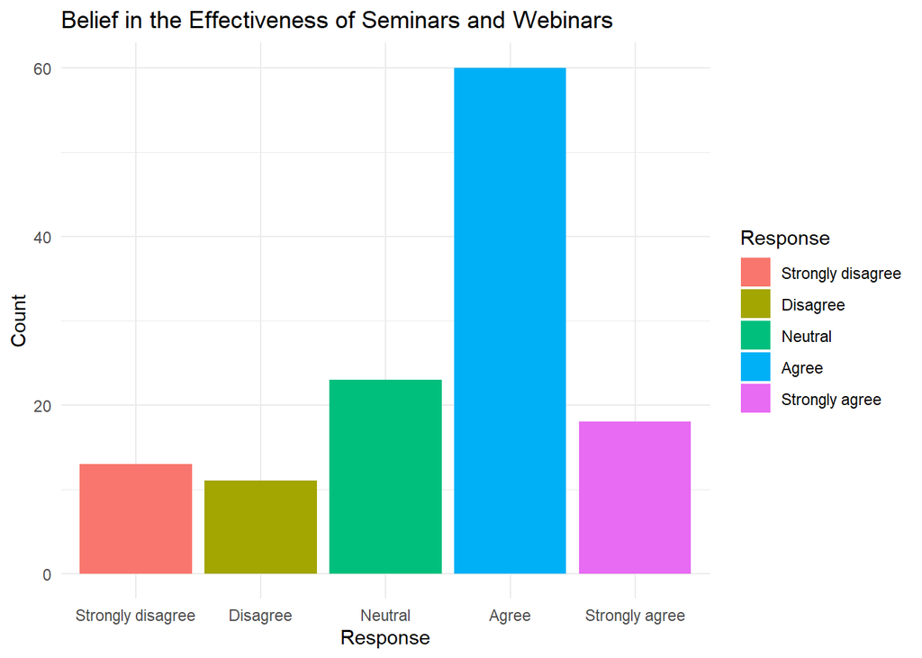

```r
believe_frequency <- data$Perception.of.Webinars...Seminars..I.believe.seminars.and.webinars.are.effective.for.enhancing.student.engagement.
belief_df <- data.frame(Response = believe_frequency)
belief_df$Response <- factor(belief_df$Response, levels = c("Strongly disagree", "Disagree", "Neutral", "Agree", "Strongly agree"))
ggplot(belief_df, aes(x = Response, fill = Response)) +
  geom_bar(stat = "count") +
  labs(title = "Belief in the Effectiveness of Seminars and Webinars", x = "Response", y = "Count") +
  theme_minimal()
```

The graph is showing the distribution of people’s beliefs about the effectiveness of seminars and webinars for enhancing student engagement. By looking at the heights of the bars for each belief level, you can get an idea of how many people in the dataset hold a particular belief. For example, if the bar is tall for “Agree,” it means that a significant number of people believe that seminars and webinars are effective for enhancing student engagement.

### 2. The convenience of webinars influences students’ participation.

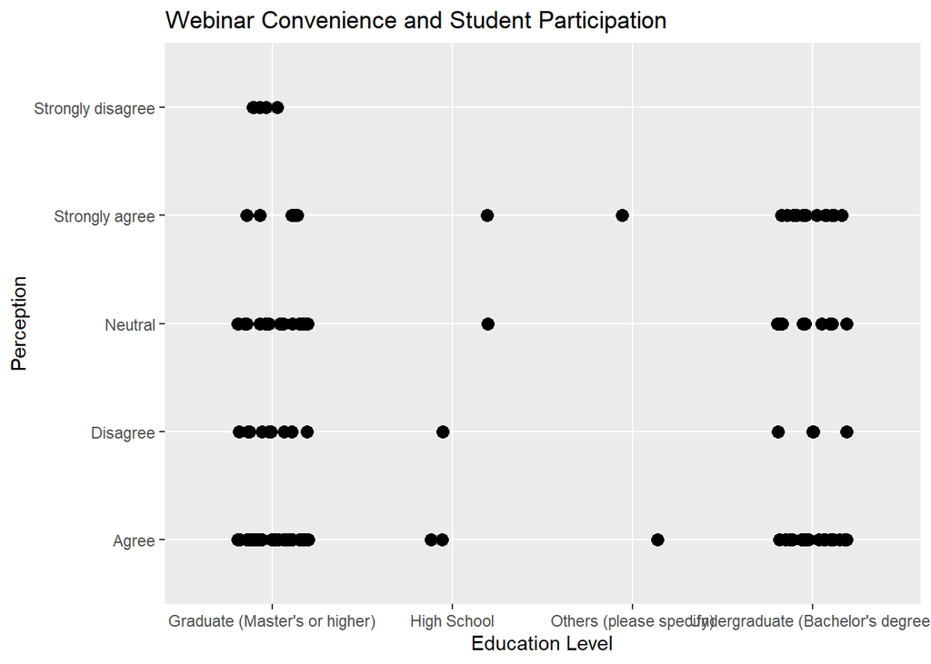

```r
ggplot(data, aes(x = as.factor(data$What.is.your.current.level.of.education.), y = as.factor(data$Perception.of.Webinars...Seminars..The.convenience.of.webinars.influences.students..participation..))) +
  #geom_count(aes(color = data$Perception.of.Webinars...Seminars..The.convenience.of.webinars.influences.students..participation.., size = 3)) +
  geom_jitter(position = position_jitter(width = 0.2, height = 0), size = 3) +
  labs(title = "Webinar Convenience and Student Participation",
       x = "Education Level",
       y = "Perception") +
  scale_color_manual(values = c("Strongly disagree" = "red",
                                "Disagree" = "orange",
                                "Neutral" = "yellow",
                                "Agree" = "green",
                                "Strongly agree" = "blue"))
```

The scatter plot shows how individuals’ education levels correlate with their perceptions of how the convenience of webinars influences student participation. It represent varying levels of agreement or disagreement, offering a visual overview of potential patterns or trends in these associations.

### 3 .Webinars are better at accommodating students’ busy schedules compared to seminars.

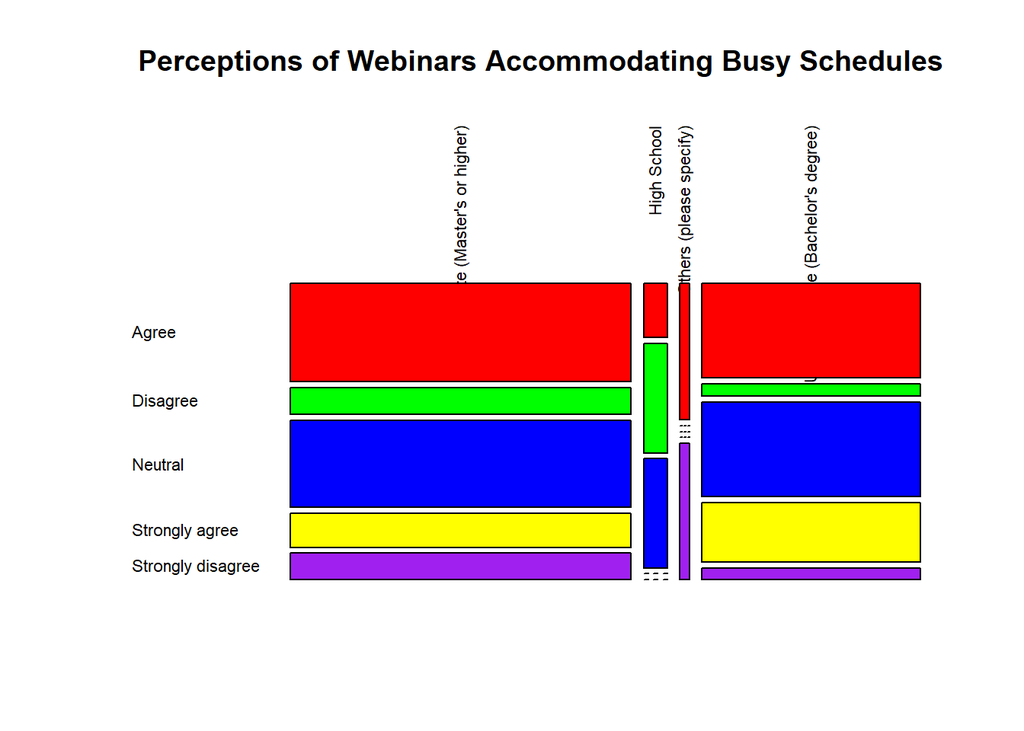

```r
temp_data <- data.frame(
  Education_Level = data$What.is.your.current.level.of.education.,
  Webinar_Response = data$Perception.of.Webinars...Seminars..Webinars.are.better.at.accommodating.students..busy.schedules.compared.to.seminars..
)

mosaicplot(table(data$What.is.your.current.level.of.education., data$Perception.of.Webinars...Seminars..Webinars.are.better.at.accommodating.students..busy.schedules.compared.to.seminars..),
           main = "Perceptions of Webinars Accommodating Busy Schedules",
           color = c("red", "green", "blue", "yellow", "purple"),
           cex.axis = 0.7,
           las = 4)
```

### 4. Peer interaction is essential for student learning in webinars.

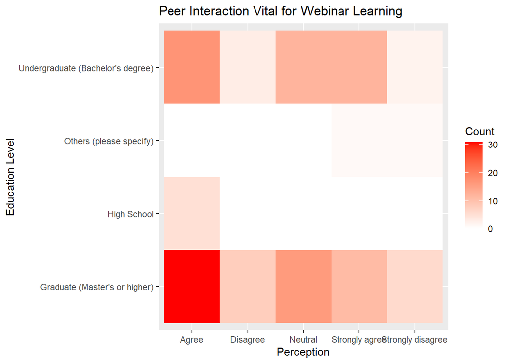

```r
heatmap_data <- table(data$What.is.your.current.level.of.education., data$Perception.of.Webinars...Seminars..Peer.interaction.is.essential.for.student.learning.in.webinars..)
heatmap_df <- as.data.frame(heatmap_data)
ggplot(heatmap_df, aes(x = Var2, y = Var1, fill = Freq)) +
  geom_tile() +
  labs(title = "Peer Interaction Vital for Webinar Learning",
       x = "Perception",
       y = "Education Level",
       fill = "Count") +
  scale_fill_gradient(low = "white", high = "red")
```

The heatmap visually represents the frequency of responses to the statement “Peer interaction is essential for student learning in webinars” across different education levels.The chart provides an overview of how the perception of the importance of peer interaction varies among different educational backgrounds. Each cell in the heatmap corresponds to a combination of education level and perception, with color intensity indicating the count of responses.

### 5. Seminars encourage active participation among students.

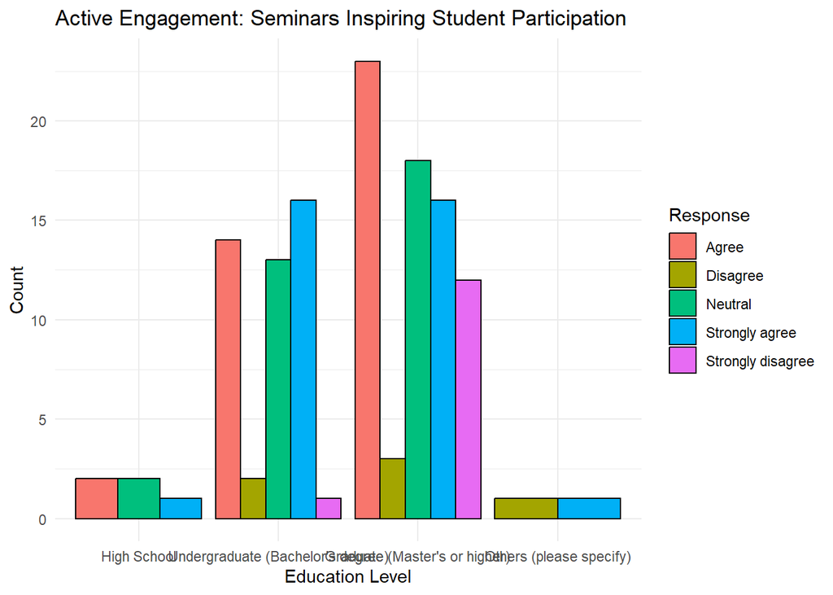

```r
education_levels <- c("High School", "Undergraduate (Bachelor's degree)", "Graduate (Master's or higher)", "Others (please specify)")

# Create a factor with specified levels
data$What.is.your.current.level.of.education. <- factor(data$What.is.your.current.level.of.education., levels = education_levels)

# Create a grouped bar chart
ggplot(data, aes(x = `What.is.your.current.level.of.education.`, fill = data$Perception.of.Webinars...Seminars..Seminars.encourage.active.participation.among.students..)) +
  geom_bar(position = "dodge", color = "black", stat = "count") +
  labs(title = "Active Engagement: Seminars Inspiring Student Participation",
       x = "Education Level",
       y = "Count",
       fill = "Response") +
  theme_minimal()
```